# Coursera’s Practical Machine Learning Course - Course Project

Diogenes A. R. Justo

Sunday, November 23, 2014

This is the course project activity to Coursera’s Course titled “Practical Machine Learning”. The goal in this project is to predict the manner how some guys did exercises. For this, we will use one data set ([Velose et al]) with a lot of information from guys that had used some eletronic gadgets to collect data from themselves making exercises.

There are 5 classes of exercises: classes A to E.

### 0. Preparing Libraries

First we load libraries that will be used on this job.

```r
library(data.table)
library(caret)
```

```r
library(ggplot2)
library(knitr)
library(xtable)
library(randomForest)
```

### 1. Getting and loading data

Be sure you get pml-training.csv and pml-testing.csv: https://d396qusza40orc.cloudfront.net/predmachlearn/pml-training.csv and; https://d396qusza40orc.cloudfront.net/predmachlearn/pml-testing.csv

Or just check-out in my repo at GitHub: https://github.com/diogenesjusto/Coursera_ML_Project

This files must bu placed on working directory (check it with getwd()).

If you have a old computer (like me) be patient because it is a mid-large dataset.

### 2. Data exploration

You can verify in a easy way that there a lot of information to work, just checking total of columns, and a large number of observations.

```r
ncol(train)
```

[output not shown]

```r
nrow(train)
```

[output not shown]

It will be a good idea to choose some algoritm that run well on this approach. I made a choice of using Random Forests.

Additionaly, checking out information, we saw a lot of NA’s data, and we must made some cleaning.

### 3. Preprocessing

For data clean we prepare a new fuction to load and clean division by zero, and after re-load data. Also we treat NA’s.

```r
read.pml <- function(file) {
fread(file, na.strings=c("#DIV/0!", ""))
}

raw.train <- read.pml("pml-training.csv")
raw.validation <- read.pml("pml-testing.csv")
set.seed(13)

## contains some NA values
na.cols <- raw.train[,sapply(.SD, function(x) any(is.na(x)))]
```

There are some columns that seems to be metadata or classifier. This columns I choose to eliminate: - unlabled row index - user_name - raw_timestamp_part_1 - raw_timestamp_part_2 - cvtd_timestamp - new_window - num_window

```r
drop.columns <- function(x) {
x[,!c("V1", "user_name", "raw_timestamp_part_1", "raw_timestamp_part_2", "cvtd_timestamp", "new_window", "num_window"),with=F]
}
transform.features <- function(x) {
x[,classe:=factor(classe)]
}
## try only columns that have values
training.features <- drop.columns(raw.train[,eval(names(which(na.cols == F))),with=F])
```

### 4. Cross Validation

Splitting the training data into two subsets (training and testing) we reach cross validation. The choice of sampling data by classe field was intended to have classes on train and test subset:

```r
in.train <- createDataPartition(training.features$classe, p=.60, list=FALSE)

train <- training.features[in.train[,1]]
test <- training.features[-in.train[,1]]
```

### 5. Random Forest Model

The random forest model is setting up by using training data. The confusion matrix showed above, tell us that accuracy of model is pretty well:

```r
model.rf <- train(y=as.factor(train$classe), x=train[,!"classe",with=F],
  tuneGrid=data.frame(mtry=3), trControl=trainControl(method="none"), method="rf")
confusionMatrix(predict(model.rf, newdata=transform.features(test)),
  factor(test$classe))
```

```
## Confusion Matrix and Statistics
##
##           Reference
## Prediction    A    B    C    D    E
##          A 2231    3    0    0    0
##          B    1 1511   10    0    0
##          C    0    4 1358   35    0
##          D    0    0    0 1248    0
##          E    0    0    0    3 1442
##
## Overall Statistics
##
##                Accuracy : 0.993
##                  95% CI : (0.991, 0.995)
##     No Information Rate : 0.284
##     P-Value [Acc > NIR] : <2e-16
##
##                   Kappa : 0.991
##  Mcnemar's Test P-Value : NA
##
## Statistics by Class:
##
##                      Class: A Class: B Class: C Class: D Class: E
## Sensitivity             1.000    0.995    0.993    0.970    1.000
## Specificity             0.999    0.998    0.994    1.000    1.000
## Pos Pred Value          0.999    0.993    0.972    1.000    0.998
## Neg Pred Value          1.000    0.999    0.998    0.994    1.000
## Prevalence              0.284    0.193    0.174    0.164    0.184
## Detection Rate          0.284    0.193    0.173    0.159    0.184
## Detection Prevalence    0.285    0.194    0.178    0.159    0.184
## Balanced Accuracy       1.000    0.997    0.993    0.985    1.000
```

### 6. Variable Importance

For analsys to variable importance, we make a plot ordered above:

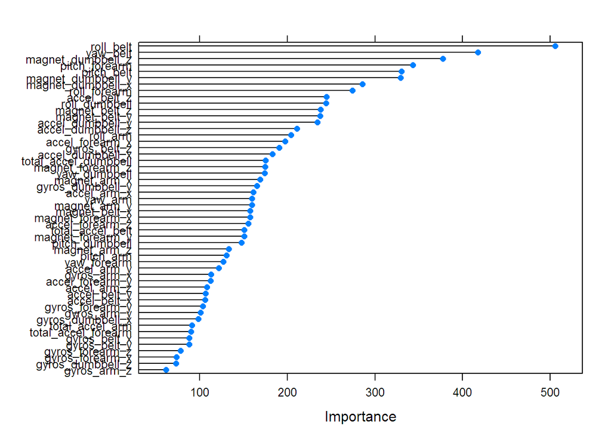

### 7. Conclusion

Verifing confusion matrix and analysing error statistics, we can conclude that this model satisfy our needs to predict classe field, and is a good prediction model to be used on 20’s rows test data set.

By submiting all results on site submission area, I reached 100% of results, verifing my hipothesis.

### References

Velloso, E.; Bulling, A.; Gellersen, H.; Ugulino, W.; Fuks, H. Qualitative Activity Recognition of Weight Lifting Exercises. Proceedings of 4th International Conference in Cooperation with SIGCHI (Augmented Human ’13) . Stuttgart, Germany: ACM SIGCHI, 2013.